# R Notebook

```r
library(plyr)
library(tidyverse)
library(ggplot2)
library(flextable)
library(metafor)
library(orchaRd)
```

### 1. Correct analysis of Clark et al. (2020) data (i.e., OA_activitydat_20190302_BIOL3207.csv) to generate the summary statistics (means, SD, N) for each of the fish species’ average activity for each treatment.

```r
oa.csv <- read.csv("OA_activitydat_20190302_BIOL3207.csv", stringsAsFactors = TRUE) %>% drop_na()
head(oa.csv)
```

|  | X | loc | species | treatment | animal_id | sl | size | activity | comment |
| --- | --- | --- | --- | --- | --- | --- | --- | --- | --- |
| 1 | 1 | LIRS 2014 | ambon | CO2 | 64 | 56.98794 | big | 8.147368 | 27min means of sml+lrg dur, from All Lizard activity data for JJ v2_7 Jun 2017.xlsx |
| 2 | 2 | LIRS 2014 | ambon | CO2 | 65 | 38.23816 | big | 10.505263 | 27min means of sml+lrg dur, from All Lizard activity data for JJ v2_7 Jun 2017.xlsx |
| 3 | 3 | LIRS 2014 | ambon | CO2 | 67 | 39.30947 | big | 6.513043 | 27min means of sml+lrg dur, from All Lizard activity data for JJ v2_7 Jun 2017.xlsx |
| 4 | 4 | LIRS 2014 | ambon | CO2 | 68 | 36.07155 | big | 27.836364 | 27min means of sml+lrg dur, from All Lizard activity data for JJ v2_7 Jun 2017.xlsx |
| 5 | 5 | LIRS 2014 | lemon | CO2 | 74 | 36.43578 | big | 36.682609 | 27min means of sml+lrg dur, from All Lizard activity data for JJ v2_7 Jun 2017.xlsx |
| 6 | 6 | LIRS 2014 | ambon | CO2 | 75 | 35.88814 | big | 42.796154 | 27min means of sml+lrg dur, from All Lizard activity data for JJ v2_7 Jun 2017.xlsx |

```r
st.sum <- ddply(oa.csv, c('treatment', "species"), summarize, n = length(activity), mean = mean(activity), sd = sd(activity))
ft <- flextable(st.sum)
ft
```

| treatment | species | n | mean | sd |
| --- | --- | --- | --- | --- |
| CO2 | acantho | 86 | 27.30042 | 10.415559 |
| CO2 | ambon | 22 | 18.39429 | 12.200326 |
| CO2 | chromis | 14 | 24.78010 | 10.975005 |
| CO2 | humbug | 62 | 40.28306 | 11.915992 |
| CO2 | lemon | 19 | 26.04157 | 10.957164 |
| CO2 | whitedams | 60 | 24.45733 | 9.950437 |
| control | acantho | 90 | 28.92639 | 11.246347 |
| control | ambon | 21 | 17.34102 | 11.451588 |
| control | chromis | 20 | 26.09986 | 9.125352 |
| control | humbug | 65 | 34.91652 | 13.867278 |
| control | lemon | 30 | 19.79766 | 12.256353 |
| control | whitedams | 61 | 26.58624 | 10.936592 |

```r
st.sum
```

| treatment | species | n | mean | sd |
| --- | --- | --- | --- | --- |
| CO2 | acantho | 86 | 27.30042 | 10.415559 |
| CO2 | ambon | 22 | 18.39429 | 12.200326 |
| CO2 | chromis | 14 | 24.78010 | 10.975005 |
| CO2 | humbug | 62 | 40.28306 | 11.915992 |
| CO2 | lemon | 19 | 26.04157 | 10.957164 |
| CO2 | whitedams | 60 | 24.45733 | 9.950437 |
| control | acantho | 90 | 28.92639 | 11.246347 |
| control | ambon | 21 | 17.34102 | 11.451588 |
| control | chromis | 20 | 26.09986 | 9.125352 |
| control | humbug | 65 | 34.91652 | 13.867278 |

[output cut: 2 more lines]

acantho = Acanthochromis; Ambon = Pomacentrus amboinensis; Chromis = Chromis atripectoralis; Humbug = Dascyllus aruanus; Lemon = Pomacentrus moluccensis

```r
st.sum <- st.sum %>% mutate(species=case_when(species == "acantho" ~ "Acanthochromis polyacanthus",
                                              species == "ambon" ~ "Pomacentrus amboinensis",
                                              species == "chromis" ~ "Chromis atripectoralis",
                                              species == "humbug" ~ "Dascyllus aruanus",
                                              species == "lemon" ~ "Pomacentrus moluccensis",
                                              species == "whitedams" ~ "Dischistodus perspicillatus"),
                            treatment=case_when(treatment == "CO2" ~ "oa",
                                                treatment == "control" ~ "ctrl"))
```

```r
st.sum
```

| treatment | species | n | mean | sd |
| --- | --- | --- | --- | --- |
| oa | Acanthochromis polyacanthus | 86 | 27.30042 | 10.415559 |
| oa | Pomacentrus amboinensis | 22 | 18.39429 | 12.200326 |
| oa | Chromis atripectoralis | 14 | 24.78010 | 10.975005 |
| oa | Dascyllus aruanus | 62 | 40.28306 | 11.915992 |
| oa | Pomacentrus moluccensis | 19 | 26.04157 | 10.957164 |
| oa | Dischistodus perspicillatus | 60 | 24.45733 | 9.950437 |
| ctrl | Acanthochromis polyacanthus | 90 | 28.92639 | 11.246347 |
| ctrl | Pomacentrus amboinensis | 21 | 17.34102 | 11.451588 |
| ctrl | Chromis atripectoralis | 20 | 26.09986 | 9.125352 |
| ctrl | Dascyllus aruanus | 65 | 34.91652 | 13.867278 |

[output cut: 2 more lines]

```r
st.order <- pivot_wider(data = st.sum, names_from = "treatment", values_from = c("n", "mean", "sd") ,names_sep = ".")
```

```r
colnames(st.order) <- c("Species", "oa.n", "ctrl.n", "oa.mean", "ctrl.mean", "oa.sd", "ctrl.sd")
st.order
```

| Species | oa.n | ctrl.n | oa.mean | ctrl.mean | oa.sd | ctrl.sd |
| --- | --- | --- | --- | --- | --- | --- |
| Acanthochromis polyacanthus | 86 | 90 | 27.30042 | 28.92639 | 10.415559 | 11.246347 |
| Pomacentrus amboinensis | 22 | 21 | 18.39429 | 17.34102 | 12.200326 | 11.451588 |
| Chromis atripectoralis | 14 | 20 | 24.78010 | 26.09986 | 10.975005 | 9.125352 |
| Dascyllus aruanus | 62 | 65 | 40.28306 | 34.91652 | 11.915992 | 13.867278 |
| Pomacentrus moluccensis | 19 | 30 | 26.04157 | 19.79766 | 10.957164 | 12.256353 |
| Dischistodus perspicillatus | 60 | 61 | 24.45733 | 26.58624 | 9.950437 | 10.936592 |

### 2. Through coding, merge the summary statistics generated from 1) with the metadata (i.e., clark_paper_data.csv) from Clark et al. (2020).

```r
meta.csv.92 <- read.csv("clark_paper_data.csv", stringsAsFactors = TRUE)
meta.csv.92$Cue.stimulus.type <- "Predator"
glimpse(meta.csv.92)
```

```
Rows: 1
Columns: 15
$ Study              <fct> a92
$ Authors            <fct> Clark et al
$ Year..online.      <int> 2020
$ Year..print.       <int> 2020
$ Title              <fct> Ocean acidification does not impair the behaviour of coral reef fishes
$ Journal            <fct> Nature
$ Pub.year.IF        <dbl> 69.5
$ X2017.IF           <dbl> 41.58
$ Average.n          <int> 45
$ Effect.type        <fct> Weak
$ Climate..FishBase. <fct> Trop
$ Env.cue.stimulus.  <fct> No
$ Cue.stimulus.type  <chr> "Predator"
$ Behavioural.metric <fct> Activity
$ Life.stage         <fct> Adult
```

```r
meta.92 <- merge(meta.csv.92, st.order)
meta.92
```

| Study | Authors | Year..online. | Year..print. | Title | Journal | Pub.year.IF | X2017.IF | Average.n | Effect.type | Climate..FishBase. | Env.cue.stimulus. | Cue.stimulus.type | Behavioural.metric | Life.stage | Species | oa.n | ctrl.n | oa.mean | ctrl.mean | oa.sd | ctrl.sd |
| --- | --- | --- | --- | --- | --- | --- | --- | --- | --- | --- | --- | --- | --- | --- | --- | --- | --- | --- | --- | --- | --- |
| a92 | Clark et al | 2020 | 2020 | Ocean acidification does not impair the behaviour of coral reef fishes | Nature | 69.5 | 41.58 | 45 | Weak | Trop | No | Predator | Activity | Adult | Acanthochromis polyacanthus | 86 | 90 | 27.30042 | 28.92639 | 10.415559 | 11.246347 |
| a92 | Clark et al | 2020 | 2020 | Ocean acidification does not impair the behaviour of coral reef fishes | Nature | 69.5 | 41.58 | 45 | Weak | Trop | No | Predator | Activity | Adult | Pomacentrus amboinensis | 22 | 21 | 18.39429 | 17.34102 | 12.200326 | 11.451588 |
| a92 | Clark et al | 2020 | 2020 | Ocean acidification does not impair the behaviour of coral reef fishes | Nature | 69.5 | 41.58 | 45 | Weak | Trop | No | Predator | Activity | Adult | Chromis atripectoralis | 14 | 20 | 24.78010 | 26.09986 | 10.975005 | 9.125352 |
| a92 | Clark et al | 2020 | 2020 | Ocean acidification does not impair the behaviour of coral reef fishes | Nature | 69.5 | 41.58 | 45 | Weak | Trop | No | Predator | Activity | Adult | Dascyllus aruanus | 62 | 65 | 40.28306 | 34.91652 | 11.915992 | 13.867278 |
| a92 | Clark et al | 2020 | 2020 | Ocean acidification does not impair the behaviour of coral reef fishes | Nature | 69.5 | 41.58 | 45 | Weak | Trop | No | Predator | Activity | Adult | Pomacentrus moluccensis | 19 | 30 | 26.04157 | 19.79766 | 10.957164 | 12.256353 |
| a92 | Clark et al | 2020 | 2020 | Ocean acidification does not impair the behaviour of coral reef fishes | Nature | 69.5 | 41.58 | 45 | Weak | Trop | No | Predator | Activity | Adult | Dischistodus perspicillatus | 60 | 61 | 24.45733 | 26.58624 | 9.950437 | 10.936592 |

### 3. Through coding, correctly merge the combined summary statistics and metadata from Clark et al. (2020) (output from 1 & 2) into the larger meta-analysis dataset (i.e., ocean_meta_data.csv).

```r
meta.csv <- read.csv("ocean_meta_data.csv", stringsAsFactors = TRUE)
levels(meta.csv$Species)
```

```
 [1] "Acanthochromis polyacanthus"    "Acanthopagrus schlegelii"       "Amphiprion melanopus"
 [4] "Amphiprion percula"             "Anguilla anguilla"              "Apogon cyanosoma"
 [7] "Argyrosomus japonicus"          "Argyrosomus regius"             "Atherina presbyter"
[10] "Boreogadus saida"               "Cephalopholis cyanostigma"      "Cheilodipterus quinquelineatus"
[13] "Chromis punctipinnis"           "Chromis viridis"                "Citharichthys stigmaeus"
[16] "Clupea harengus"                "Coryphaena hippurus"            "Ctenolabrus rupestris"
[19] "Dascyllus aruanus"              "Dicentrachus labrax"            "Dicentrarchus labrax"
[22] "Engraulis japonicus"            "Favonigobius lateralis"         "Forsterygion lapillum"
[25] "Gadus macrocephalus"            "Gadus morhua"                   "Gasterosteus aculeatus"
[28] "Gobius bucchichi"               "Gobiusculus flavescens"         "Hemiscyllium ocellatum"
[31] "Heterodontus portusjacksoni"    "Hippocampus guttulatus\xca"     "Lates calcarifer"
[34] "Mustelus canis"                 "Neopomacentrus azysron"         "Not provided"
[37] "Plectropomus leopardus"         "Pomacentrus amboinensis"        "Pomacentrus chrysurus"
[40] "Pomacentrus moluccensis"        "Pomacentrus nagasakiensis"      "Pomacentrus wardi"
[43] "Pomatoschistus pictus"          "Pseudochromis fuscus"           "Rachycentron canadum"
[46] "Scyliorhinus canicula"          "Sebastes diploproa"             "Sebastes spp."
[49] "Seriola lalandi"                "Solea senegalensis"             "Sparus aurata"
[52] "Symphodus ocellatus"            "Syngnathus typhle"              "Theragra chalcogramma"
[55] "Trematomus bernacchii"          "Vincentia badia"
```

```r
meta.csv$Pub.year.IF <- meta.csv$Pub.year.IF %>% as.numeric()
meta.csv$X2017.IF <- meta.csv$X2017.IF %>% as.numeric()
```

```r
meta.all <- bind_rows(meta.csv, meta.92)
glimpse(meta.all)
```

```
Rows: 824
Columns: 22
```

```
$ Study              <fct> a1, a1, a1, a1, a1, a1, a1, a2, a2, a2, a2, a2, a2, a2, a2, a2, a2, a2, a2, a3, a3, a3, a3, a3, a3, a3, a…
$ Authors            <fct> Munday et al, Munday et al, Munday et al, Munday et al, Munday et al, Munday et al, Munday et al, Dixson …
$ Year..online.      <int> 2009, 2009, 2009, 2009, 2009, 2009, 2009, 2009, 2009, 2009, 2009, 2009, 2009, 2009, 2009, 2009, 2009, 200…
$ Year..print.       <int> 2009, 2009, 2009, 2009, 2009, 2009, 2009, 2010, 2010, 2010, 2010, 2010, 2010, 2010, 2010, 2010, 2010, 201…
$ Title              <fct> "Ocean acidification impairs olfactory discrimination and homing ability of marine fish.", "Ocean acidifi…
$ Journal            <fct> PNAS, PNAS, PNAS, PNAS, PNAS, PNAS, PNAS, Ecol Lett, Ecol Lett, Ecol Lett, Ecol Lett, Ecol Lett, Ecol Let…
$ Pub.year.IF        <dbl> 68, 68, 68, 68, 68, 68, 68, 9, 9, 9, 9, 9, 9, 9, 9, 9, 9, 9, 9, 69, 69, 69, 69, 69, 69, 69, 69, 69, 69, 6…
$ X2017.IF           <dbl> 35, 35, 35, 35, 35, 35, 35, 34, 34, 34, 34, 34, 34, 34, 34, 34, 34, 34, 34, 35, 35, 35, 35, 35, 35, 35, 3…
$ Average.n          <int> 27, 27, 27, 27, 27, 27, 27, 15, 15, 15, 15, 15, 15, 15, 15, 15, 15, 15, 15, 18, 18, 18, 18, 18, 18, 18, 1…
$ Effect.type        <fct> Strong, Strong, Strong, Strong, Strong, Strong, Strong, Strong, Strong, Strong, Strong, Strong, Strong, S…
$ Species            <chr> "Amphiprion percula", "Amphiprion percula", "Amphiprion percula", "Amphiprion percula", "Amphiprion percu…
$ Climate..FishBase. <fct> Trop, Trop, Trop, Trop, Trop, Trop, Trop, Trop, Trop, Trop, Trop, Trop, Trop, Trop, Trop, Trop, Trop, Tro…
$ Env.cue.stimulus.  <fct> Yes, Yes, Yes, Yes, Yes, Yes, Yes, Yes, Yes, Yes, Yes, Yes, Yes, Yes, Yes, Yes, Yes, Yes, Yes, Yes, Yes, …
$ Cue.stimulus.type  <chr> "Habitat", "Habitat", "Habitat", "Habitat", "Kin", "Kin", "Kin", "Predator", "Predator", "Predator", "Pre…
$ Behavioural.metric <fct> "% time in Xanthostemon cue", "% time in Melaleuca cue", "% time in Grass cue", "% time in anemone cue", …
$ Life.stage         <fct> Larvae, Larvae, Larvae, Larvae, Larvae, Larvae, Larvae, Larvae, Larvae, Larvae, Larvae, Larvae, Larvae, L…
$ ctrl.n             <int> 26, 20, 20, 10, 30, 30, 30, 45, 45, 45, 45, 45, 45, 45, 45, 45, 45, 45, 45, 22, 22, 22, 22, 22, 22, 22, 2…
$ ctrl.mean          <dbl> 94.1290, 0.7830, 46.3800, 98.8260, 0.9120, 90.8760, 96.3500, 9.6470, 10.0640, 14.0540, 12.9730, 11.1110, …
$ ctrl.sd            <dbl> 2.9931, 3.5017, 14.0023, 1.8563, 2.9960, 3.9984, 3.9984, 10.6459, 0.0067, 3.6291, 10.8807, 7.0973, 0.0007…
$ oa.n               <int> 46, 46, 46, 16, 20, 20, 20, 45, 45, 45, 45, 45, 45, 45, 45, 45, 45, 45, 45, 22, 22, 22, 22, 22, 22, 22, 2…
$ oa.mean            <dbl> 72.7890, 83.5620, 71.4290, 88.2580, 99.8180, 99.8180, 49.6350, 7.9370, 10.5820, 14.5160, 1.6130, 11.1110,…
$ oa.sd              <dbl> 13.2730, 10.6211, 13.2730, 7.0440, 0.0045, 0.0045, 2.4463, 7.0973, 7.0973, 3.6090, 0.0007, 0.0067, 7.0973…
```

### 4. Correctly calculate the log response ratio (lnRR) effect size for every row of the dataframe using metafor’s escalc() function.

```r
meta.lrr <- escalc(measure="ROM", m1i=ctrl.mean, m2i=oa.mean, sd1i=ctrl.sd, sd2i=oa.sd, n1i=ctrl.n, n2i=oa.n, var.names = c("LRR", "LRR_var"), data=meta.all) %>% drop_na() %>% subset(LRR_var < 10) # restrict the size of standard error
```

```r
meta.lrr$residual <- 1:dim(meta.lrr)[1]
```

### 5. Correct meta-analytic model fitted to the data that controls for the sampling variance of lnRR. The model should include a random effect of study and observation. Use metafor’s rma.mv() function.

1. Glance the $I^2$

```r
meta.FE <- rma(LRR, LRR_var,method = 'FE',data = meta.lrr)
summary(meta.FE)
```

```
Fixed-Effects Model (k = 788)

         logLik         deviance              AIC              BIC             AICc
-368043952.5901   736089059.7934   736087907.1801   736087911.8496   736087907.1852

I^2 (total heterogeneity / total variability):   100.00%
H^2 (total variability / sampling variability):  935310.11

Test for Heterogeneity:
Q(df = 787) = 736089059.7935, p-val < .0001

Model Results:

estimate      se          zval    pval    ci.lb    ci.ub
 -0.6802  0.0000  -416857.7418  <.0001  -0.6802  -0.6802  ***

---
Signif. codes:  0 ‘***’ 0.001 ‘**’ 0.01 ‘*’ 0.05 ‘.’ 0.1 ‘ ’ 1
```

$I^2$ is too high to use FE model, choose REML instead.

multilevel test

```r
names(meta.all)
```

```
 [1] "Study"              "Authors"            "Year..online."      "Year..print."       "Title"              "Journal"
 [7] "Pub.year.IF"        "X2017.IF"           "Average.n"          "Effect.type"        "Species"            "Climate..FishBase."
[13] "Env.cue.stimulus."  "Cue.stimulus.type"  "Behavioural.metric" "Life.stage"         "ctrl.n"             "ctrl.mean"
[19] "ctrl.sd"            "oa.n"               "oa.mean"            "oa.sd"
```

```r
meta.ml <- rma.mv(LRR, LRR_var, method = "REML", random = list(~1 | Study, ~1 | residual), dfs = "contain", test = "t", data = meta.lrr)
meta.ml
```

```
Multivariate Meta-Analysis Model (k = 788; method: REML)

Variance Components:

            estim    sqrt  nlvls  fixed    factor
sigma^2.1  0.4702  0.6857     92     no     Study
sigma^2.2  4.0229  2.0057    788     no  residual

Test for Heterogeneity:
Q(df = 787) = 736089059.7934, p-val < .0001

Model Results:

estimate      se     tval  df    pval    ci.lb   ci.ub
 -0.1300  0.1128  -1.1526  91  0.2521  -0.3541  0.0940

---
Signif. codes:  0 ‘***’ 0.001 ‘**’ 0.01 ‘*’ 0.05 ‘.’ 0.1 ‘ ’ 1
```

### 6. Written paragraph of the findings and what they mean which is supported with a figure. The paragraph should include:

1. Correct presentation and interpretation of overall meta-analytic mean and measures of uncertainty around the mean estimate (e.g., 95% confidence intervals).

For the different studies, the effect size is -0.1300, the standard error is 0.1128, the t-value is -1.1526, the p-val is 0.2521 > 0.05 which means that the $H_0$:the value of LRR are 0 cannot be rejected, the 95% confidence interval is from -0.3541 to 0.0940 which means the LRR value have 95% possibility located in this range. the p-value in the heterogeneity test is less than 0.0001 which means that there is a heterogeneity generally while it cannot be confirmed that which level has the huge heterogeneity.

2. Measures of heterogeneity in effect size estimates across studies (i.e., I2 and/or prediction intervals - see predict() function in metafor)

```r
i2_ml(meta.ml, data = meta.lrr)
```

```
   I2_Total    I2_Study I2_residual
  100.00000    10.46555    89.53445
```

```r
pis <- predict(meta.ml, transf = "transf.logit")
pis
```

[output not shown]

```
NA
```

[figure not shown]

```r
forest(meta.ml)
```

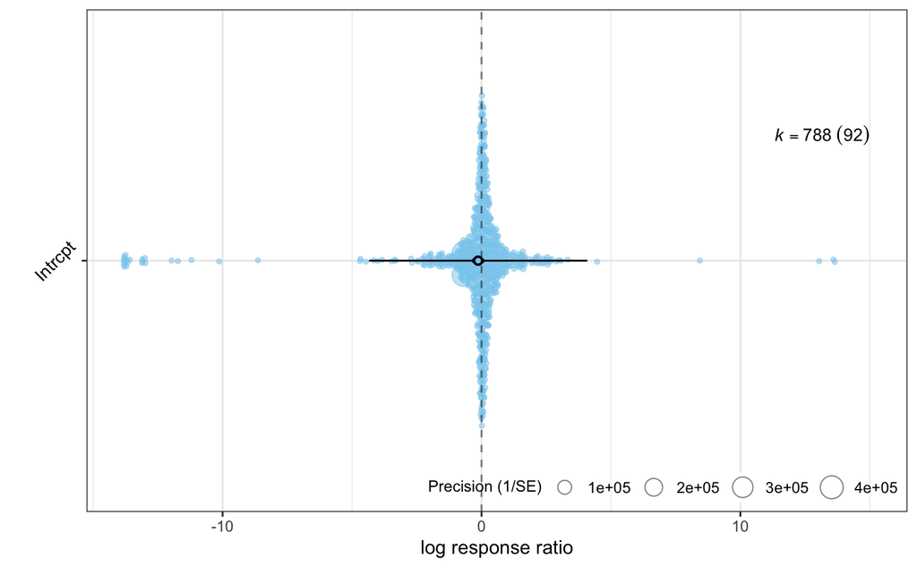

```r
orchard_plot(meta.ml, group = "Study" , data = meta.lrr,
    xlab = "log response ratio", angle = 45)
```

```r
meta.lt <- rma.mv(LRR~Life.stage, LRR_var, method = "REML", random = list(~1 | Study, ~1 | residual), dfs = "contain", test = "t", data = meta.lrr)
meta.lt
```

```
Multivariate Meta-Analysis Model (k = 788; method: REML)

Variance Components:

            estim    sqrt  nlvls  fixed    factor
sigma^2.1  0.4500  0.6709     92     no     Study
sigma^2.2  4.0307  2.0077    788     no  residual

Test for Residual Heterogeneity:
QE(df = 784) = 735922567.1399, p-val < .0001

Test of Moderators (coefficients 2:4):
F(df1 = 3, df2 = 88) = 1.2434, p-val = 0.2989

Model Results:
```

|  | estimate | se | tval | df | pval | ci.lb | ci.ub |  |
| --- | --- | --- | --- | --- | --- | --- | --- | --- |
| intrcpt | 0.1296 | 0.2349 | 0.5515 | 88 | 0.5827 | -0.3373 | 0.5965 |  |
| Life.stageJuvenile | -0.1802 | 0.2976 | -0.6055 | 88 | 0.5464 | -0.7717 | 0.4113 |  |
| Life.stageLarvae | -0.5342 | 0.2999 | -1.7814 | 88 | 0.0783 | -1.1302 | 0.0618 | . |
| Life.stageNot provided | -0.0489 | 0.5929 | -0.0825 | 88 | 0.9344 | -1.2272 | 1.1294 |  |

```
---
Signif. codes:  0 ‘***’ 0.001 ‘**’ 0.01 ‘*’ 0.05 ‘.’ 0.1 ‘ ’ 1
```

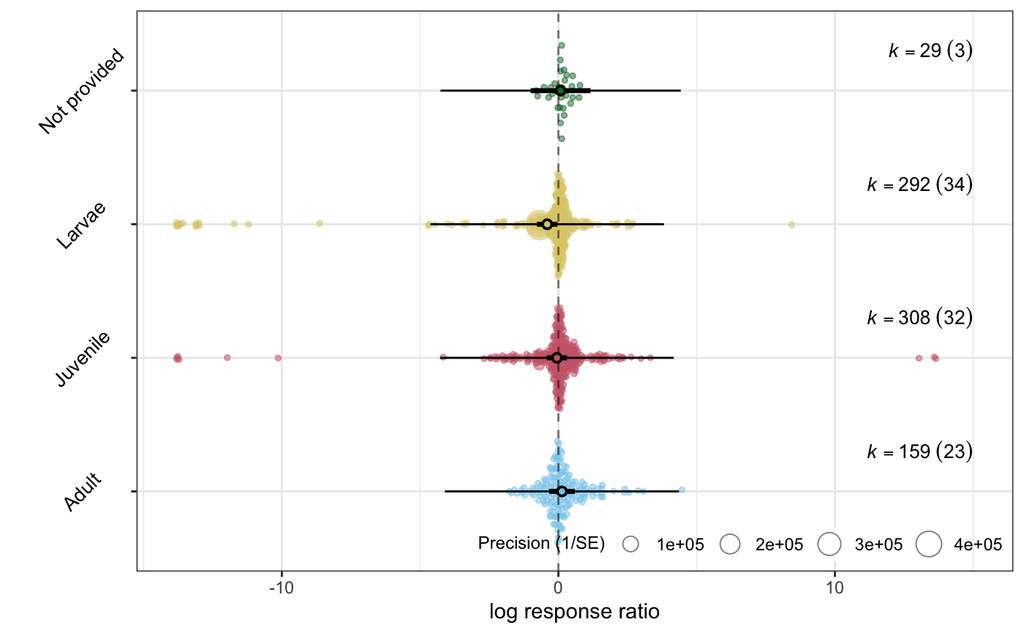

```r
orchard_plot(meta.lt, group = "Study" ,mod = "Life.stage", data = meta.lrr,
    xlab = "log response ratio", angle = 45)
```